# Breast Cancer Classification

Logistic Regression vs Random Forest — Wisconsin Breast Cancer Dataset

Author

Petros Kogios

Published

May 15, 2026

## Methods Summary

The analysis employed the Wisconsin Breast Cancer dataset, derived from digitized fine needle aspirate (FNA) images of breast masses, to train and evaluate binary classifiers distinguishing malignant from benign tumors. The dataset comprised 569 samples in total, of which 212 were labeled malignant and 357 benign, representing a moderate class imbalance with a roughly 37-to-63 ratio. Each sample was described by 30 numerical features encoding cell nucleus characteristics — including radius, texture, perimeter, area, smoothness, compactness, concavity, concave points, symmetry, and fractal dimension — each computed as a mean, standard error, and worst (most extreme) value across the nuclei present in the image. The dataset was partitioned into a training set of 455 samples and a held-out test set of 114 samples, the latter containing 42 malignant and 72 benign cases.

Two classifiers were evaluated: a logistic regression model with standard scaling applied to input features, and a random forest ensemble. Model selection was conducted using stratified 5-fold cross-validation on the training set, with area under the receiver operating characteristic curve (ROC AUC) as the primary optimization metric. Stratified sampling ensured that the malignant-to-benign ratio was preserved across all folds. Final performance was assessed on the held-out test set using accuracy, AUC, precision, recall, and F1 score, with particular attention to recall for the malignant class given its clinical relevance in a screening context.

## Model Comparison

During stratified 5-fold cross-validation, logistic regression achieved a mean ROC AUC of 0.9958 (SD = 0.0047) across folds, with individual fold AUCs ranging from 0.9871 to 1.0000. The random forest produced a comparable but slightly lower mean AUC of 0.9889 (SD = 0.0070), with fold AUCs ranging from 0.9833 to 1.0000. Although the difference in mean AUC was modest at approximately 0.007, logistic regression also exhibited lower variance across folds, suggesting marginally more stable generalization under cross-validation. On this basis, logistic regression was designated the best-performing model.

On the held-out test set, both models achieved identical overall accuracy of 96.49%. Logistic regression recorded a test AUC of 0.9960, precision of 0.975, recall of 0.929, and an F1 score of 0.951. Its confusion matrix indicated one false positive and three false negatives among the 114 test cases. The random forest attained a test AUC of 0.9942 with perfect precision of 1.000, but a lower recall of 0.905 and an F1 score of 0.950, reflecting zero false positives but four false negatives. In a clinical screening setting where failing to detect a malignant case carries greater consequence than a false positive, the logistic regression’s superior recall of 0.929 versus 0.905 is a meaningful distinction, even though the absolute difference amounts to a single additional true positive in this test set.

## Feature Interpretation

The prominence of “worst” features — representing the largest or most extreme values observed across nuclei in a given sample — suggests that the most atypical nucleus within a mass, rather than the average nucleus, carries disproportionate diagnostic signal. This finding is consistent with the biological principle that malignant tumors exhibit heterogeneous cellular populations, and that the most aberrant cells may be most informative for classification. It should be noted, however, that Gini-based importance in random forests can overestimate the contribution of high-cardinality continuous features and does not directly quantify the direction or magnitude of each feature’s effect on the predicted probability; logistic regression coefficients would provide a complementary, more directly interpretable view of feature influence.

## Limitations

Several methodological limitations constrain the generalizability of the findings reported here. Most critically, the analysis was conducted on a single, well-curated benchmark dataset of 569 samples originating from one institution, and no external validation on an independent cohort was performed. Performance metrics — including the near-perfect cross-validation AUC of 0.9958 for logistic regression — should therefore be interpreted as characteristic of this specific dataset rather than as estimates of real-world clinical performance. The relatively small test set of 114 samples, containing only 42 malignant cases, means that performance estimates carry considerable statistical uncertainty; a difference of one or two cases in the confusion matrix corresponds to a meaningful shift in recall or precision.

## Figures

### ROC Curves

Both models achieve AUC > 0.99 on the holdout test set. Logistic Regression (blue) maintains a slightly higher true positive rate at low false positive rates, consistent with its superior recall for the malignant class.

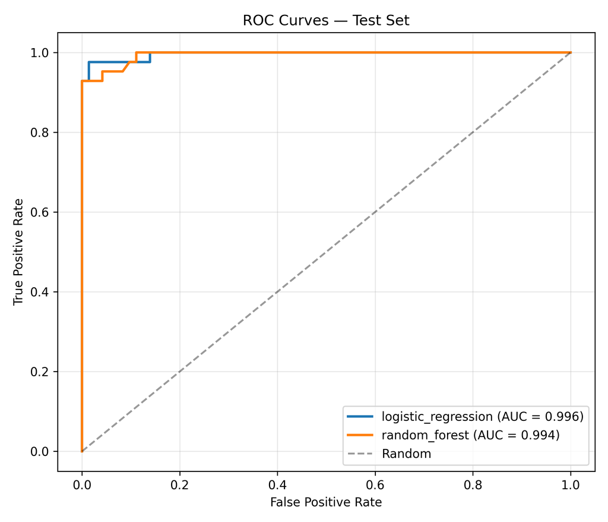

ROC Curves — Test Set

### Confusion Matrices

Identical accuracy (96.5%) but different error profiles: Logistic Regression produces 3 false negatives and 1 false positive; Random Forest produces 4 false negatives and 0 false positives. In screening contexts, the lower false negative count of Logistic Regression is clinically preferable.

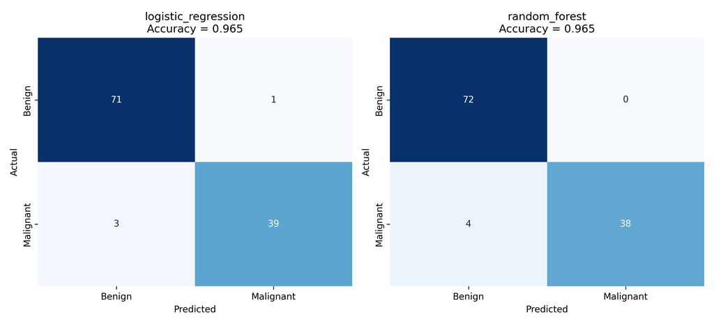

Confusion Matrices

### Feature Importance (Random Forest)

Worst-case nucleus measurements dominate. The top 3 features — worst perimeter, worst area, and worst concave points — account for approximately 39% of total Gini impurity reduction, reflecting the known pathological pattern of larger, more irregular nuclei in malignant tumors.

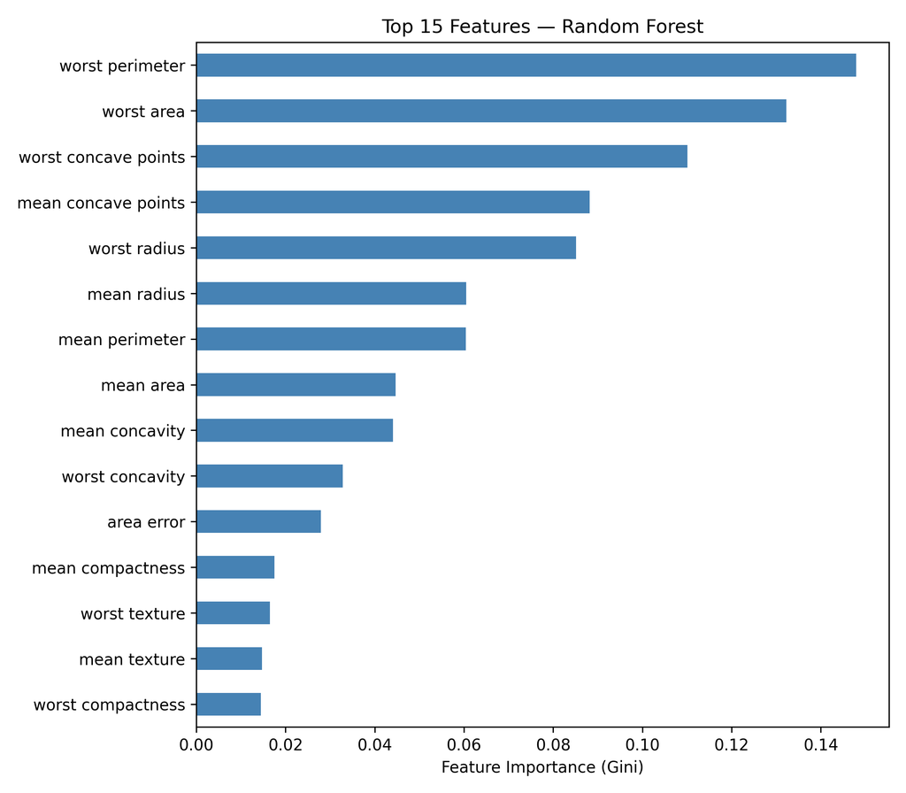

Top 15 Features by Gini Importance

## Performance Summary

| Model | CV AUC (mean ± SD) | Test AUC | Accuracy | Recall | FN |
| --- | --- | --- | --- | --- | --- |
| **Logistic Regression** | **0.9958 ± 0.0047** | **0.9960** | 96.5% | **0.929** | **3** |
| Random Forest | 0.9889 ± 0.0070 | 0.9942 | 96.5% | 0.905 | 4 |

*FN = false negatives (missed malignancies) on 114-sample holdout test set.* *CV = stratified 5-fold cross-validation on 455-sample training set.*

## Reproducibility

```bash
conda activate bioagent-r
python projects/02-breast-cancer-ml/scripts/01_train_classifier.py
python agents/ml_results_agent.py
quarto render projects/02-breast-cancer-ml/report/report.qmd
```

## Reference

Street WN, Wolberg WH, Mangasarian OL. *Nuclear feature extraction for breast tumor diagnosis.* IS&T/SPIE Int Symp Electronic Imaging. 1993;1905:861-870.